# Tarea1-AlanGutierrez

## Ejercicio 4

El primer filtro en un puesto de vacunación contra covid, consiste en preguntar a las personas si han presentado en la última semana alguno de los síntomas asociados a la enfermedad como tos y fiebre. Si alguna persona ha presentado al menos uno de estos síntomas, se le invita a pasar a responder un cuestionario más detallado con profesionales de la salud para decidir si es conveniente vacunarlo o no. Si de registros previos se sabe que el 97% de las personas que acuden a vacunarse no han presentado síntomas en la última semana:

1. Calcule la probabilidad de que se necesiten encuestar a 100 personas para encontrar a la primera que pasará a responder el cuestionario detallado.
2. Calcule la probabilidad de que la 50° persona sea la primera que pasará a responder el cuestionario detallado.
3. Calcule la probabilidad de que la primera persona encuestada sea la primera que pasará a responder el cuestionario detallado.
4. Grafique la función de probabilidad (o densidad) utilizada.

Solucion. 1. Para este inciso tenemos una distribución geométrica con probabilidad $p=0.03$ para que una persona responda el cuestionario detallado.

$X =$ número de personas antes de que la primera persona deba responder un cuestionario, entonces $X \sim Geom(x,p=0.03)$

Queremos calcular $P[X = 99] = f(99)$

```r
dgeom(x=99, prob=0.03)
```

```
## [1] 0.001470696
```

2. Queremos calcular $P[X = 49] = f(49)$

```r
dgeom(x=49, prob=0.03)
```

```
## [1] 0.00674429
```

3. Queremos calcular $P[X = 0] = f(0)$

```r
dgeom(x=0, prob=0.03)
```

```
## [1] 0.03
```

```r
x <- seq(0, 100, 1)
tabla.prob <- data.frame( x = x, probabilidad = dgeom(x=x, prob = 0.03))
tabla.prob
```

```
##       x probabilidad
## 1     0  0.030000000
## 2     1  0.029100000
## 3     2  0.028227000
## 4     3  0.027380190
## 5     4  0.026558784
## 6     5  0.025762021
## 7     6  0.024989160
## 8     7  0.024239485
## 9     8  0.023512301
## 10    9  0.022806932
## 11   10  0.022122724
## 12   11  0.021459042
## 13   12  0.020815271
## 14   13  0.020190813
```

[output cut: 87 more lines]

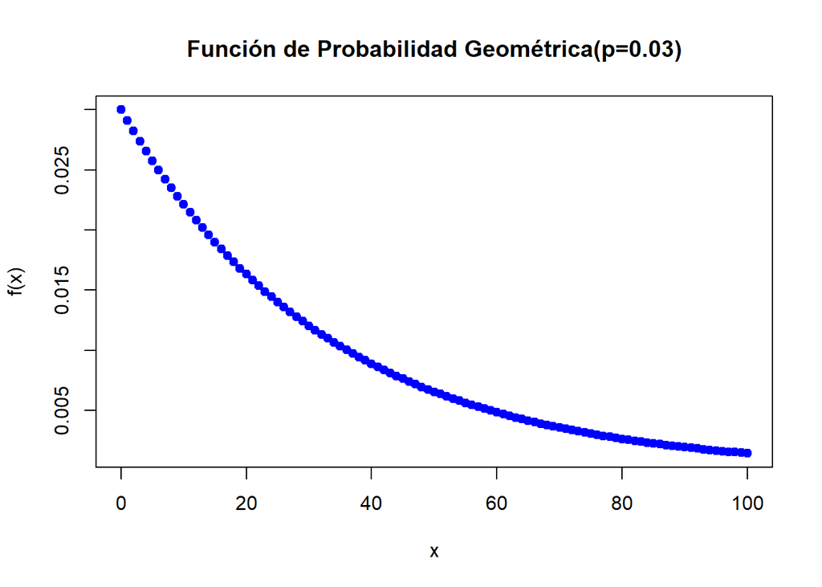

```r
plot( tabla.prob, main = "Función de Probabilidad Geométrica(p=0.03)", pch = 19, ylab = "f(x)", col ="blue")
```

## Ejercicio 5

Durante el proceso de vacunación contra covid, se aplicaron en cierto centro de salud 100 vacunas de la marca Moderna, y 200 de la marca Pfizer. Si de las 300 personas vacunadas se selecciona una muestra de 15, y se les contacta por teléfono para dar seguimiento e investigar las posibles reacciones provocadas por la vacuna:

1. Calcule la probabilidad de que todas personas seleccionadas en la muestra hayan sido vacunadas con la vacuna Moderna.
2. Calcule la probabilidad de que dos o más de las personas de la muestra hayan sido vacunadas con Moderna
3. Calcule la probabilidad de que entre 7 y 10 personas hayan sido vacunadas con Pfizer
4. Grafique la función de probabilidad (o densidad) utilizada.

Sol. 1. Aquí se tiene una situación que se puede modelar por medio de una distribución hipergeométrica con $m=100$ éxitos de la marca moderna, $n=200$ fracasos de la marca moderna (éxitos de Pfizer) y $k=15$ el tamaño de la muestra.

$X =$ número de exitos de la muestra, entonces $X \sim Hipergeométrica(m=100,n=200, k=15)$

El objetivo es calcular $P[X = 15] = f(15)$

```r
dhyper(x=15, m=100, k=15, n=200)
```

```
## [1] 3.295299e-08
```

```r
1-dhyper(x=2, m=100, k=15, n=200)
```

```
## [1] 0.943129
```

```r
phyper( q=8, m=100, k=15, n=200)- phyper(q=5, m=100, k=15, n=200)
```

```
## [1] 0.3522688
```

```r
x <- seq(0, 15, 1)
tabla.prob <- data.frame( x = x, probabilidad = dhyper(x=x, m=100, k=15, n=200))
tabla.prob
```

```
##     x probabilidad
## 1   0 1.902921e-03
## 2   1 1.534613e-02
## 3   2 5.687097e-02
## 4   3 1.284639e-01
## 5   4 1.977936e-01
## 6   5 2.198631e-01
## 7   6 1.822600e-01
## 8   7 1.147262e-01
## 9   8 5.528256e-02
## 10  9 2.039059e-02
## 11 10 5.709365e-03
## 12 11 1.191658e-03
## 13 12 1.794544e-04
## 14 13 1.840558e-05
## 15 14 1.149523e-06
## 16 15 3.295299e-08
```

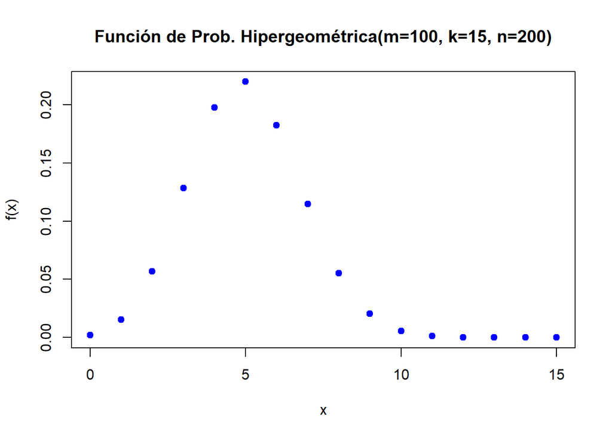

```r
plot( tabla.prob, main = "Función de Prob. Hipergeométrica(m=100, k=15, n=200)", pch = 19, ylab = "f(x)", col ="blue")
```